# Assignment 2

Author

Jazmin Hernandez

# **Assignment 02 - Data Viz and Wrangling**

## Data Wrangling

```r
library(dplyr)
library(readr)
individual_data <- "C:/Users/jhern/Downloads/chs_individual.csv"
regional_data <- "C:/Users/jhern/Downloads/chs_regional.csv"
individual_data <- read_csv(individual_data)
regional_data <- read_csv(regional_data)
```

```r
merged_data <- left_join(individual_data, regional_data, by = "townname")
head(merged_data)
```

```
# A tibble: 6 × 49
    sid townname   male race  hispanic agepft height weight   bmi asthma
  <dbl> <chr>     <dbl> <chr>    <dbl>  <dbl>  <dbl>  <dbl> <dbl>  <dbl>
1     1 Lancaster     1 W            0  10.2     123     54  16.2      0
2     2 Lancaster     1 W            0  10.5     145     77  16.6      0
3     6 Lancaster     0 B            0  10.1     145    143  30.9      0
4     7 Lancaster     0 O            0  10.7     156     72  13.4      0
5     8 Lancaster     0 W            1   9.78    132     61  15.9      0
6    10 Lancaster     1 O            1  NA        NA     NA  NA        0
# ℹ 39 more variables: active_asthma <dbl>, father_asthma <dbl>,
#   mother_asthma <dbl>, wheeze <dbl>, hayfever <dbl>, allergy <dbl>,
#   educ_parent <dbl>, smoke <dbl>, pets <dbl>, gasstove <dbl>, fev <dbl>,
#   fvc <dbl>, mmef <dbl>, pm25_mass <dbl>, pm25_so4 <dbl>, pm25_no3 <dbl>,
#   pm25_nh4 <dbl>, pm25_oc <dbl>, pm25_ec <dbl>, pm25_om <dbl>, pm10_oc <dbl>,
#   pm10_ec <dbl>, pm10_tc <dbl>, formic <dbl>, acetic <dbl>, hcl <dbl>,
#   hno3 <dbl>, o3_max <dbl>, o3106 <dbl>, o3_24 <dbl>, no2 <dbl>, …
```

```r
row_count <- nrow(merged_data)
cat("Rows in merged_data:", row_count, "\n")
```

```
Rows in merged_data: 1200
```

```r
duplicate_count <- sum(duplicated(merged_data))
cat("Number of duplicate rows in merged_data:", duplicate_count, "\n")
```

```
Number of duplicate rows in merged_data: 0
```

```r
Mode <- function(x) {
  x <- x[!is.na(x)]
  uniq_x <- unique(x)
  if (length(uniq_x) == 0) return(NA)
  uniq_x[which.max(tabulate(match(x, uniq_x)))]
}
```

```r
merged_data |>
group_by(male, hispanic) |>
mutate(
across(where(is.numeric),
           ~ if_else(is.na(.), mean(., na.rm = TRUE), .)),
across(where(is.character),
           ~ if_else(is.na(.), Mode(.), .))
  ) |>
  ungroup()
```

```
# A tibble: 1,200 × 49
     sid townname   male race  hispanic agepft height weight   bmi asthma
   <dbl> <chr>     <dbl> <chr>    <dbl>  <dbl>  <dbl>  <dbl> <dbl>  <dbl>
 1     1 Lancaster     1 W            0  10.2    123    54    16.2      0
 2     2 Lancaster     1 W            0  10.5    145    77    16.6      0
 3     6 Lancaster     0 B            0  10.1    145   143    30.9      0
 4     7 Lancaster     0 O            0  10.7    156    72    13.4      0
 5     8 Lancaster     0 W            1   9.78   132    61    15.9      0
 6    10 Lancaster     1 O            1   9.97   139.   82.8  19.4      0
 7    13 Lancaster     1 O            1  10.2    140    79    18.3      0
 8    16 Lancaster     0 W            0  10.4    141    74    16.9      1
 9    19 Lancaster     0 W            0   9.85   139.   77.4  18.1      0
10    21 Lancaster     0 W            1   9.94   126    59    16.9      0
# ℹ 1,190 more rows
# ℹ 39 more variables: active_asthma <dbl>, father_asthma <dbl>,
#   mother_asthma <dbl>, wheeze <dbl>, hayfever <dbl>, allergy <dbl>,
#   educ_parent <dbl>, smoke <dbl>, pets <dbl>, gasstove <dbl>, fev <dbl>,
#   fvc <dbl>, mmef <dbl>, pm25_mass <dbl>, pm25_so4 <dbl>, pm25_no3 <dbl>,
#   pm25_nh4 <dbl>, pm25_oc <dbl>, pm25_ec <dbl>, pm25_om <dbl>, pm10_oc <dbl>,
#   pm10_ec <dbl>, pm10_tc <dbl>, formic <dbl>, acetic <dbl>, hcl <dbl>, …
```

```r
missing_values_count <- colSums(is.na(merged_data))
print(missing_values_count)
```

```
          sid      townname          male          race      hispanic
            0             0             0             0             0
       agepft        height        weight           bmi        asthma
           89            89            89            89            31
active_asthma father_asthma mother_asthma        wheeze      hayfever
            0           106            56            71           118
      allergy   educ_parent         smoke          pets      gasstove
           63            64            40             0            33
          fev           fvc          mmef     pm25_mass      pm25_so4
           95            97           106             0             0
     pm25_no3      pm25_nh4       pm25_oc       pm25_ec       pm25_om
            0             0             0             0             0
      pm10_oc       pm10_ec       pm10_tc        formic        acetic
            0             0             0             0             0
          hcl          hno3        o3_max         o3106         o3_24
            0             0             0             0             0
          no2          pm10       no_24hr      pm2_5_fr         iacid
            0             0           100           300             0
        oacid   total_acids           lon           lat
            0             0             0             0
```

```r
merged_data <- merged_data |>
mutate(obesity_level = case_when(
    bmi < 14 ~ "Underweight",
    bmi >= 14 & bmi <= 22 ~ "Normal",
    bmi > 22 & bmi <= 24 ~ "Overweight",
    bmi > 24 ~ "Obese",
    TRUE ~ NA_character_
  ))
```

```r
summary_table <- merged_data |>
group_by(obesity_level) |>
summarize(
min_bmi = min(bmi, na.rm = TRUE),
max_bmi = max(bmi, na.rm = TRUE),
total_observations = n(),
.groups = 'drop'
  )
print(summary_table)
```

```
# A tibble: 5 × 4
  obesity_level min_bmi max_bmi total_observations
  <chr>           <dbl>   <dbl>              <int>
1 Normal           14.0    22.0                886
2 Obese            24.0    41.3                103
3 Overweight       22.0    24.0                 87
4 Underweight      11.3    14.0                 35
5 <NA>            Inf    -Inf                   89
```

```r
merged_data <- merged_data|>
  mutate(smoke_gas_exposure = case_when(
    smoke == 0 & gasstove == 0 ~ "Non-exposed",
    smoke == 1 & gasstove == 0 ~ "Second Hand Smoke Only",
    smoke == 0 & gasstove == 1 ~ "Gas Stove Only",
    smoke == 1 & gasstove == 1 ~ "Both Exposures",
    TRUE ~ NA_character_
  ))
head(merged_data)
```

```
# A tibble: 6 × 51
    sid townname   male race  hispanic agepft height weight   bmi asthma
  <dbl> <chr>     <dbl> <chr>    <dbl>  <dbl>  <dbl>  <dbl> <dbl>  <dbl>
1     1 Lancaster     1 W            0  10.2     123     54  16.2      0
2     2 Lancaster     1 W            0  10.5     145     77  16.6      0
3     6 Lancaster     0 B            0  10.1     145    143  30.9      0
4     7 Lancaster     0 O            0  10.7     156     72  13.4      0
5     8 Lancaster     0 W            1   9.78    132     61  15.9      0
6    10 Lancaster     1 O            1  NA        NA     NA  NA        0
# ℹ 41 more variables: active_asthma <dbl>, father_asthma <dbl>,
#   mother_asthma <dbl>, wheeze <dbl>, hayfever <dbl>, allergy <dbl>,
#   educ_parent <dbl>, smoke <dbl>, pets <dbl>, gasstove <dbl>, fev <dbl>,
#   fvc <dbl>, mmef <dbl>, pm25_mass <dbl>, pm25_so4 <dbl>, pm25_no3 <dbl>,
#   pm25_nh4 <dbl>, pm25_oc <dbl>, pm25_ec <dbl>, pm25_om <dbl>, pm10_oc <dbl>,
#   pm10_ec <dbl>, pm10_tc <dbl>, formic <dbl>, acetic <dbl>, hcl <dbl>,
#   hno3 <dbl>, o3_max <dbl>, o3106 <dbl>, o3_24 <dbl>, no2 <dbl>, …
```

```r
summary_town <- merged_data |>
group_by(townname) |>
summarize(
average_fev = mean(fev, na.rm = TRUE),
sd_fev = sd(fev, na.rm = TRUE),
.groups = 'drop'
  )
print(summary_town)
```

```
# A tibble: 12 × 3
   townname      average_fev sd_fev
   <chr>               <dbl>  <dbl>
 1 Alpine              2089.   298.
 2 Atascadero          2079.   332.
 3 Lake Elsinore       2040.   318.
 4 Lake Gregory        2092.   338.
 5 Lancaster           2003.   337.
 6 Lompoc              2038.   367.
 7 Long Beach          1984.   331.
 8 Mira Loma           1985.   337.
 9 Riverside           1986.   290.
10 San Dimas           2028.   322.
11 Santa Maria         2023.   330.
12 Upland              2027.   357.
```

```r
summary_sex <- merged_data |>
group_by(male) |>
summarize(
average_fev = mean(fev, na.rm = TRUE),
sd_FEV1 = sd(fev, na.rm = TRUE),
.groups = 'drop'
  )
print(summary_sex)
```

```
# A tibble: 2 × 3
   male average_fev sd_FEV1
  <dbl>       <dbl>   <dbl>
1     0       1959.    327.
2     1       2104.    318.
```

```r
summary_obesity <- merged_data |>
group_by(obesity_level) |>
summarize(
average_fev = mean(fev, na.rm = TRUE),
sd_fev = sd(fev, na.rm = TRUE),
.groups = 'drop'
  )
print(summary_obesity)
```

```
# A tibble: 5 × 3
  obesity_level average_fev sd_fev
  <chr>               <dbl>  <dbl>
1 Normal              1998.   309.
2 Obese               2269.   326.
3 Overweight          2224.   317.
4 Underweight         1687.   300.
5 <NA>                 NaN     NA
```

```r
summary_exposure <- merged_data |>
group_by(smoke_gas_exposure) |>
summarize(
average_fev = mean(fev, na.rm = TRUE),
sd_fev = sd(fev, na.rm = TRUE),
.groups = 'drop'
  )
print(summary_exposure)
```

```
# A tibble: 5 × 3
  smoke_gas_exposure     average_fev sd_fev
  <chr>                        <dbl>  <dbl>
1 Both Exposures               2020.   313.
2 Gas Stove Only               2026.   328.
3 Non-exposed                  2060.   343.
4 Second Hand Smoke Only       2064.   333.
5 <NA>                         2000.   365.
```

## Looking at the Data (EDA)

1. What is the association between BMI and FEV (forced expiratory volume)? From the scatter plot of BMI vs FEV, there does appear to be a positive correlation where as BMI increases, so does forced expiratory volume.

```r
colSums(is.na(merged_data|> select(bmi, fev)))
```

```
bmi fev
 89  95
```

```r
merged_data <- na.omit(merged_data)
```

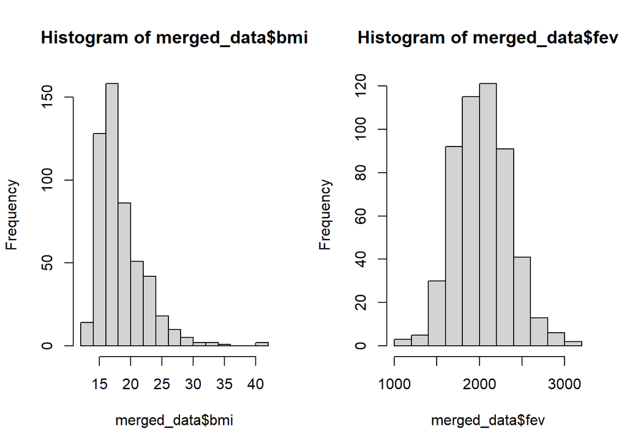

```r
layout(matrix(1:2, nrow=1))
hist(merged_data$bmi)
hist(merged_data$fev)
```

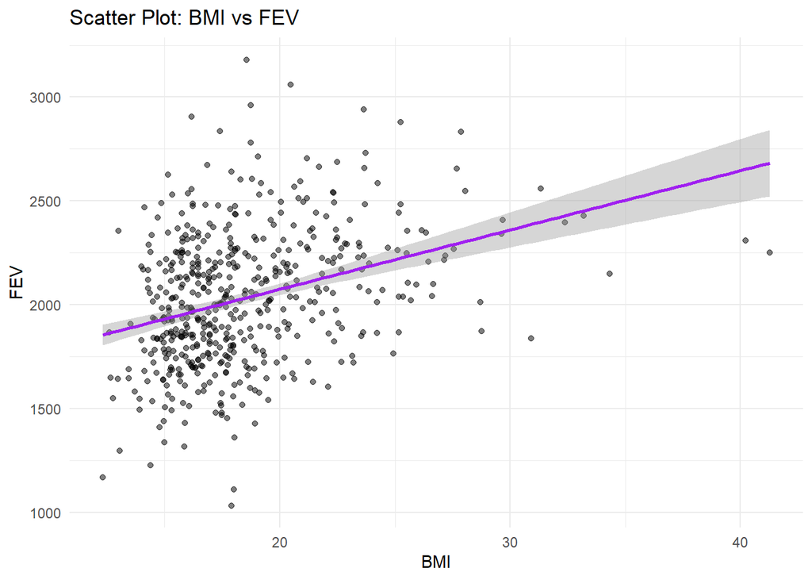

```r
library(ggplot2)
ggplot(merged_data, aes(x = bmi, y = fev)) +
  geom_point(alpha = 0.5) +
  geom_smooth(method = "lm", color = "purple") +
  labs(title = "Scatter Plot: BMI vs FEV", x = "BMI", y = "FEV") +
  theme_minimal()
```

2. What is the association between smoke and gas exposure and FEV? From the box plot, there does not appear to be an association between smoke and gas exposure and forced expiratory volume. This is because of the considerable overlapping among all four categories smoke and gas exposure.

```r
colSums(is.na(merged_data|> select(smoke_gas_exposure, fev)))
```

```
smoke_gas_exposure                fev
                 0                  0
```

```r
merged_data <- na.omit(merged_data)
```

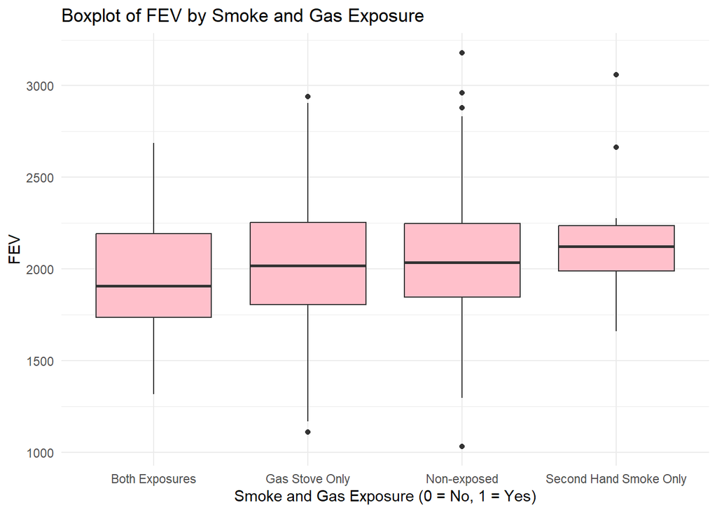

```r
ggplot(merged_data, aes(x = factor(smoke_gas_exposure), y = fev)) +
geom_boxplot(fill = "pink") +
labs(title = "Boxplot of FEV by Smoke and Gas Exposure",
x = "Smoke and Gas Exposure (0 = No, 1 = Yes)", y = "FEV") +
theme_minimal()
```

3. What is the association between PM2.5 exposure and FEV? From the scatterplot, there appears to be no association between PM 2.5 exposure and forced expiratory exposure as seen by the linear model only having a very slight decrease from 10 to about 33 pm2.5 exposure.

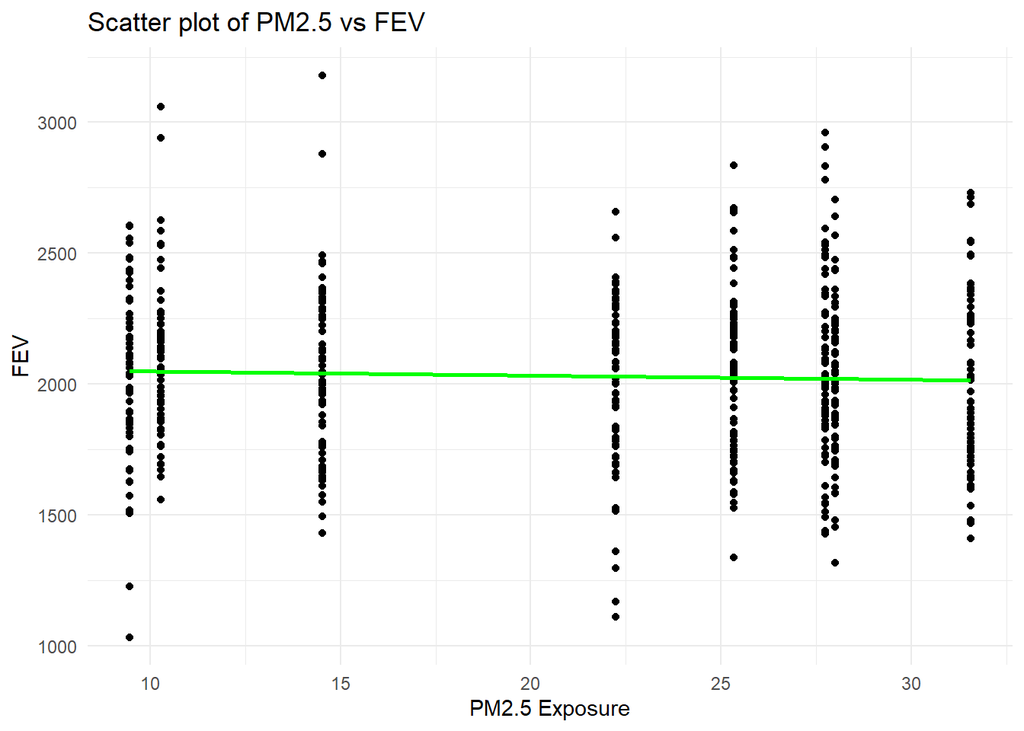

```r
ggplot(merged_data, aes(x = pm2_5_fr, y = fev)) +
  geom_point() +
  geom_smooth(method = "lm", se = FALSE, color = "green") +
  labs(title = "Scatter plot of PM2.5 vs FEV", x = "PM2.5 Exposure", y = "FEV") +
  theme_minimal()
```

## Visualization

1. Facet plot showing scatterplots with regression lines of BMI vs FEV by “townname”. All scatterplots do show an association between BMI and FEV. We can see that throughout all towns, as BMI increases, so does forced expiratory volume. However, in areas such as Riverside and Alpine, this association seems more gradual.

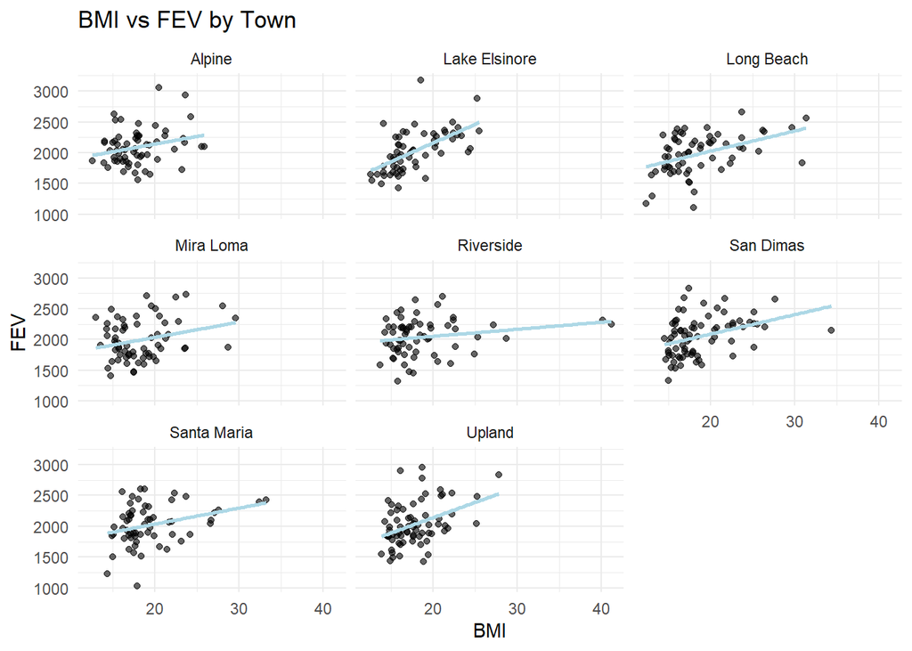

```r
ggplot(merged_data, aes(x = bmi, y = fev)) +
geom_point(alpha = 0.6) +
geom_smooth(method = "lm", se = FALSE, color = "lightblue") +
facet_wrap(~ townname) +
labs(
    title = "BMI vs FEV by Town",
    x = "BMI",
    y = "FEV",
  ) +
  theme_minimal()
```

2. Stacked histograms of FEV by BMI category and FEV by smoke/gas exposure. Use different color schemes than the ggplot default.

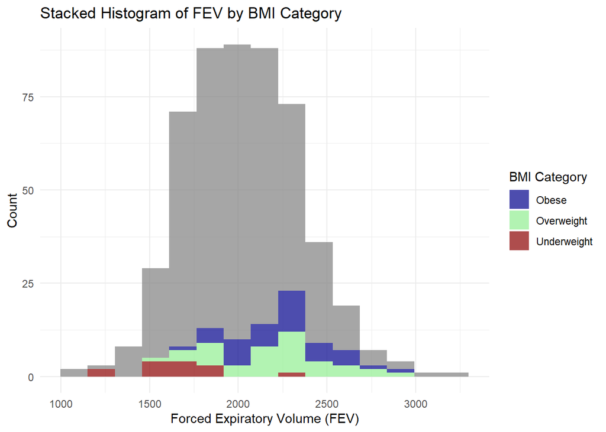

```r
ggplot(merged_data, aes(x = fev, fill = obesity_level)) +
  geom_histogram(position = "stack", bins = 15, alpha = 0.7) +
  scale_fill_manual(values = c("Underweight" = "darkred",
                                "Normal weight" = "lavender",
                                "Overweight" = "lightgreen",
                                "Obese" = "darkblue")) +
  labs(
    title = "Stacked Histogram of FEV by BMI Category",
    x = "Forced Expiratory Volume (FEV)",
    y = "Count",
    fill = "BMI Category"
  ) +
  theme_minimal()
```

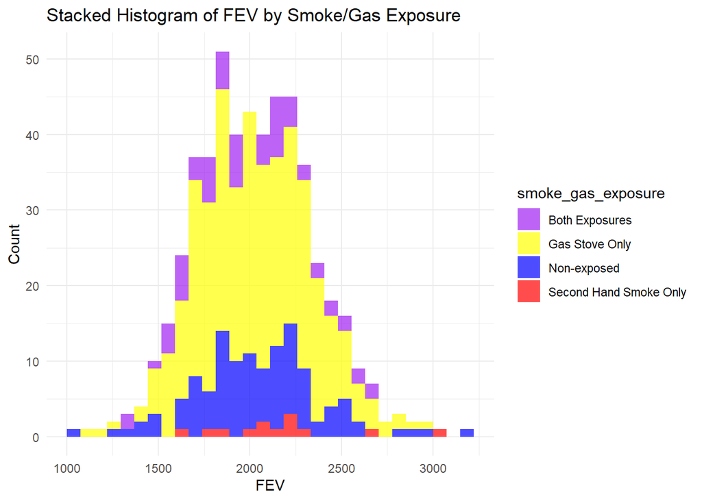

```r
ggplot(merged_data, aes(x = fev, fill = smoke_gas_exposure)) +
geom_histogram(position = "stack", bins = 30, alpha = 0.7) +
scale_fill_manual(values = c("purple", "yellow", "blue", "red")) +
labs(
title = "Stacked Histogram of FEV by Smoke/Gas Exposure",
x = "FEV",
y = "Count"
  ) +
theme_minimal()
```

3. Barchart of BMI by smoke/gas exposure. Taking the average BMI by smoke/gas exposure category we can see that there does not seem to be a significant association between smoke/gas exposure and BMI. Gas stove exposure and non-exposed are the two categories that seem to be slightly associated with a lower BMI while having both exposures and secondhand smoke only seem to be slightly more associated with higher BMI.

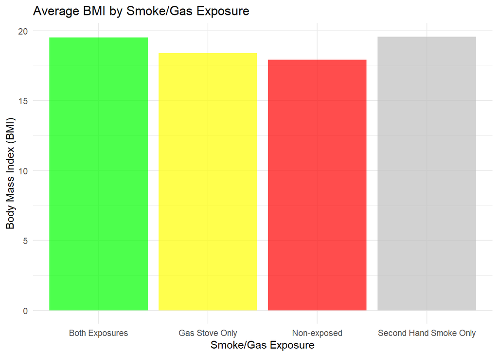

```r
bmi_summary <- merged_data |>
  group_by(smoke_gas_exposure) |>
  summarize(avg_bmi = mean(bmi, na.rm = TRUE))

ggplot(bmi_summary, aes(x = smoke_gas_exposure, y = avg_bmi, fill = smoke_gas_exposure)) +
  geom_bar(stat = "identity", alpha = 0.7) +
  scale_fill_manual(values = c("green", "yellow", "red", "grey"), name = "Smoke/Gas Exposure") +
  labs(
    title = "Average BMI by Smoke/Gas Exposure",
    x = "Smoke/Gas Exposure",
    y = "Body Mass Index (BMI)"
  ) +
  theme_minimal() +
  theme(
    legend.position = "none"  # Remove legend if not needed
  )
```

4. Statistical summary graphs of FEV by BMI and FEV by smoke/gas exposure category.

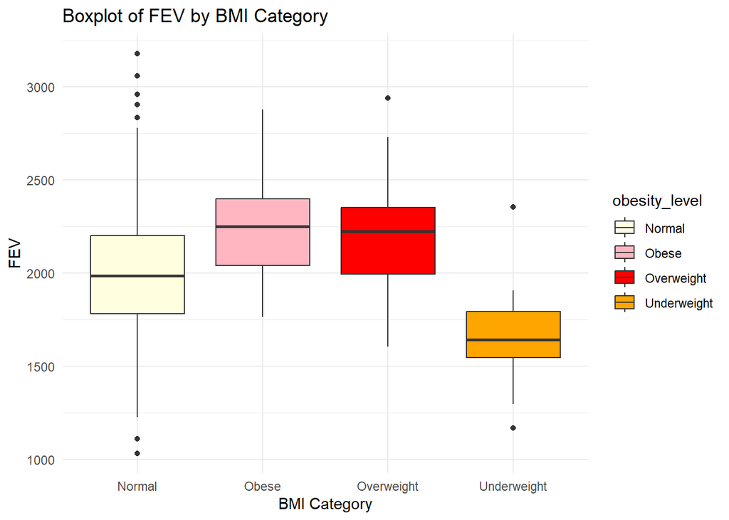

```r
ggplot(merged_data, aes(x = obesity_level, y = fev, fill = obesity_level)) +
  geom_boxplot() +
  scale_fill_manual(values = c("lightyellow", "lightpink", "red", "orange")) +
  labs(title = "Boxplot of FEV by BMI Category",
       x = "BMI Category",
       y = "FEV") +
  theme_minimal()
```

This box plot of FEV by smoke/gas exposure shows overlap between all categories of exposure. Because of this, it is likely that there is no difference between these categories in their association between FEV.

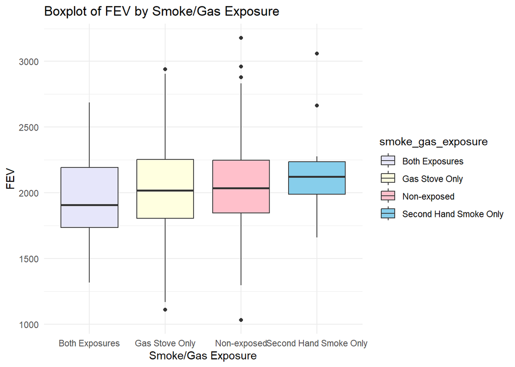

```r
ggplot(merged_data, aes(x = smoke_gas_exposure, y = fev, fill = smoke_gas_exposure)) +
  geom_boxplot() +
  scale_fill_manual(values = c("lavender", "lightyellow", "pink", "skyblue")) +
  labs(title = "Boxplot of FEV by Smoke/Gas Exposure",
       x = "Smoke/Gas Exposure",
       y = "FEV") +
  theme_minimal()
```

```r
library(leaflet)
leaflet(merged_data) |>
addTiles() |>
addCircles(lng = ~lon, lat = ~lat, weight = 1,
radius = ~pm25_mass * 100, popup = ~paste(townname, "<br>PM2.5:", pm25_mass),
color = "darkblue", fillOpacity = 0.5) |>
addLegend("bottomright", pal = colorNumeric("Blues", merged_data$pm25_mass),
values = merged_data$pm25_mass, title = "PM2.5 Concentration")
```

[interactive chart not shown]

6. Choose a visualization to examine whether PM2.5 mass is associated with FEV. The scatterplot shows that there seems to be a slightly negative association between pm2.5 mass and FEV. We can see that as mass increases, FEV slightly decreases.

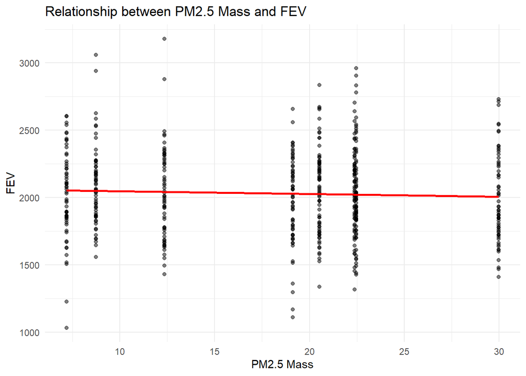

```r
ggplot(merged_data, aes(x = pm25_mass, y = fev)) +
  geom_point(alpha = 0.5) +
  geom_smooth(method = "lm", se = FALSE, color = "red") +
  labs(title = "Relationship between PM2.5 Mass and FEV",
       x = "PM2.5 Mass",
       y = "FEV") +
  theme_minimal()
```